# HMM in Marine Sciences: model selection, covariates, hierarchical structures

Marco Gallegos Herrada and Vianey Leos Barajas

```r
library(readr)
library(momentuHMM)
library(ggplot2)
library(dplyr)
library(lubridate)
library(data.tree)
```

# 1 Tutorial objectives

The goal of this tutorial is to explore how to fit hidden Markov models to accelerometer data, how to incorporate covariates into the transition probabilities, and the implementation of hierarchical Markov models to animal movement data. For the first two objectives, we will use 4 days of acceleration data obtained from a free-ranging blacktip reef shark at Palmyra Atoll in the central Pacific Ocean (data taken from Leos-Barajas et al. 2017).

# 2 Accelerometer data

Accelerometer devices measure up to three axes, which can be described relative to the body of the animal: longitudinal (surge), lateral (sway) and dorsoventral (heave). These devices are becoming more prevalent in the fields of animal biologging data as they provide a means of measuring activity in a meaningful and quantitative way. From tri-axial acceelration data, we can also derive several measures that summarize effort or exertion and relate acceleration to activity levels such as overall dynamic body acceleration (ODBA) and vectorial dynamic body acceleration (VeDBA). These metrics can be used to reduce the dimensionality of three-dimension acceleration data while retaining important information. Further, because acceleration data is often at high temporal resolutions over time, it also naturally exhibits a large degree of autocorrelation, making it impossible to assume independence between sequential observations. As we have learned, HMMs can account for the autocorrelation present in the data while assuming that the data were generated according to a finite set of (unobserved) behaviors making them a good candidate model for this type of data structure. Today, we will fit an HMM to the ODBA of a blacktip shark, calculated every second.

For the blacktip shark, we have time of day, water temperature, depth and ODBA. Since one of our goals is to use the time of observations (second of the day) as a covariate, we also need to extract this information from the time variable.

```r
# Reading the data
BlacktipB <- read_delim("data/BlacktipB.txt",
                        delim = "\t", escape_double = FALSE,
                        trim_ws = TRUE)
# Let's transform the date/time info into a proper time format
# In this case we need to extract the second of the day correspondent to each observation
BlacktipB = BlacktipB %>%
  mutate(Time = as.POSIXct(Time,format = "%m/%d/%Y %H:%M")) %>%
  mutate(hour_to_sec =  as.integer(seconds(hm(format(Time, format = "%H:%M"))))) %>%
  group_by(Time) %>% mutate(sec = row_number()) %>% ungroup() %>%
  mutate(sec = case_when(hour_to_sec == 53160 ~ as.integer(sec + 55),
                         TRUE ~ sec),
         hour_to_sec = hour_to_sec + sec)

head(BlacktipB)
```

```
## # A tibble: 6 x 6
##   Time                 Temp Depth   ODBA hour_to_sec   sec
##   <dttm>              <dbl> <dbl>  <dbl>       <int> <int>
## 1 2013-07-10 14:46:00  30.1   0.3 0.0672       53216    56
## 2 2013-07-10 14:46:00  30.1   0.3 0.0298       53217    57
## 3 2013-07-10 14:46:00  30.1   0.3 0.0422       53218    58
## 4 2013-07-10 14:46:00  30.1   0.3 0.0748       53219    59
## 5 2013-07-10 14:46:00  30.1   0.3 0.0442       53220    60
## 6 2013-07-10 14:47:00  30.1   0.3 0.0995       53221     1
```

# 3 Fitting our model

Looking at the ODBA values through the observed period, we find ODBA is unusually high at some times – for this shark we assumed that values between 0 and 2 were consistent with what we expected. Because accommodating extreme values can pose a problem for identification of an adequate state-dependent distribution in our HMM, we removed them from the data set. However, note that in general, deciding whether to remove extreme values or not will more likely depend on whether we find appropriate distributional forms that can accommodate them. Generally, we need to make sure that extreme values are in fact some artefact of the data collection process, not representative of a behavior of interest, or inconsistent with what we are trying to capture as well. Removing data is not good general practice but instead we can assess on a case-by-case basis.

We can see the original time series here across the four days:

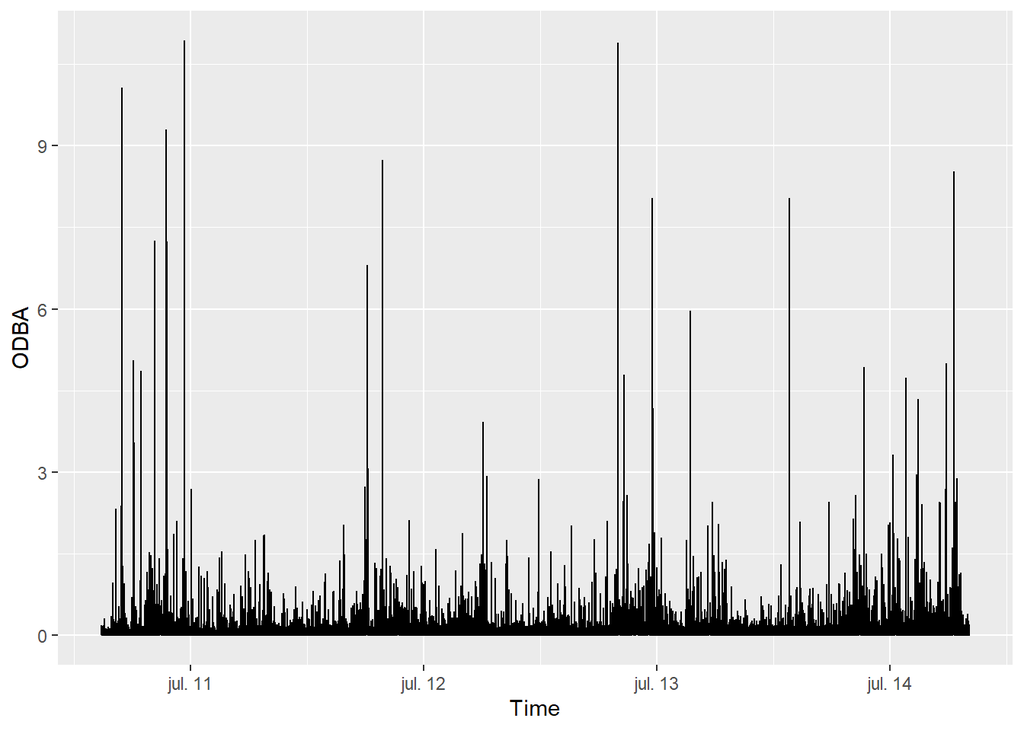

```r
BlacktipB %>% ggplot(aes(Time,ODBA)) + geom_line()
```

```r
BlacktipB = BlacktipB %>% filter(ODBA <= 2.0)
```

And now, the modified time series with values above 2.0 removed.Now, we are ready to start to look for models for this data!

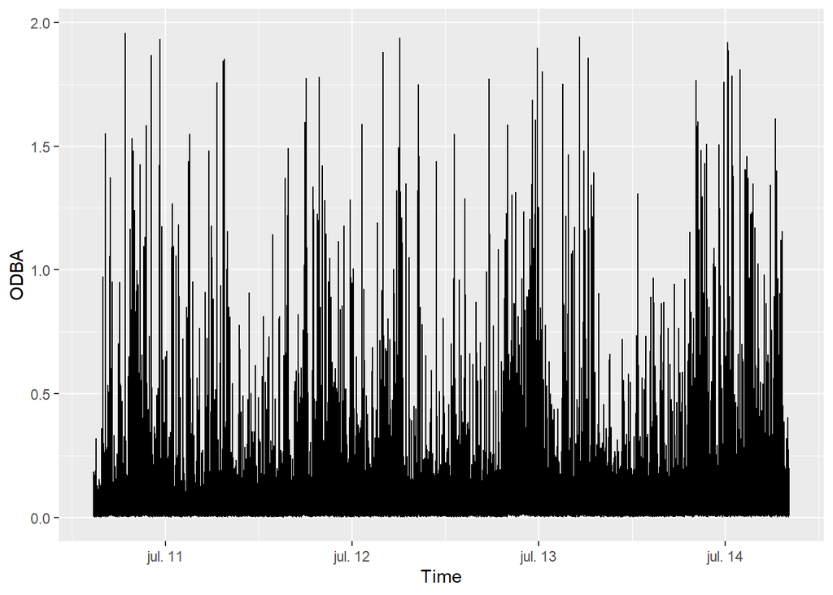

Given our data, we are interested in finding possible behaviours through the observation process (ODBA). Let’s take a quick look at the histogram of the observations.

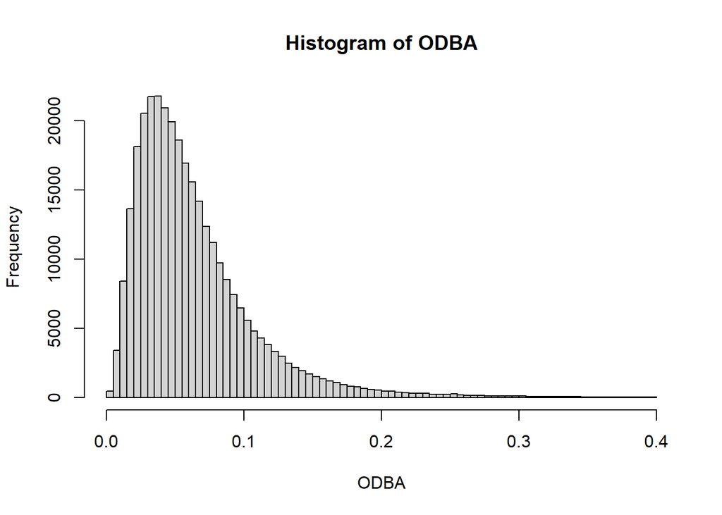

As we have indicated before, the best way to start when fitting a hidden Markov model is to keep things simple. In this case, we will be considering 2 behavioral states, with gamma state-dependent distributions, and no covariates for the transition probability matrix. As mentioned in previous tutorials, now is time to implement the decisions that we have made so far. For the choice of initial parameter values we can take a quick peak at the data (e.g., using the plots above). From the plots above, we specify the means of our state-dependent distributions as .1 and .3.

Now that the data is ready for modeling, we choose to fit a 2-state hidden Markov model. For this purpose, we first need to assign the class `momentuHMMData` to the data in order to be presentable for the functions related to `momentuHMM`.

```r
BlacktipBData = prepData(BlacktipB,coordNames = NULL,
                   covNames = "hour_to_sec")
```

Let’s take a look at the output of the fitted model.

```r
fit1 = fitHMM(BlacktipBData,nbStates=2,dist=list(ODBA="gamma"),Par0 = list(ODBA=c(.1,.3,1,1)))

fit1
```

```
## Value of the maximum log-likelihood: 632931
##
##
## ODBA parameters:
## ----------------
##         state 1    state 2
## mean 0.12024869 0.05092869
## sd   0.07916711 0.02789224
##
## Regression coeffs for the transition probabilities:
## ---------------------------------------------------
##                1 -> 2    2 -> 1
## (Intercept) -2.520214 -3.789739
##
## Transition probability matrix:
## ------------------------------
##            state 1   state 2
## state 1 0.92554680 0.0744532
## state 2 0.02210195 0.9778980
##
## Initial distribution:
## ---------------------
##   state 1   state 2
## 0.4999013 0.5000987
```

We can also plot the results to obtain a visual representation of the fitted model.

```
## Decoding state sequence... DONE
```

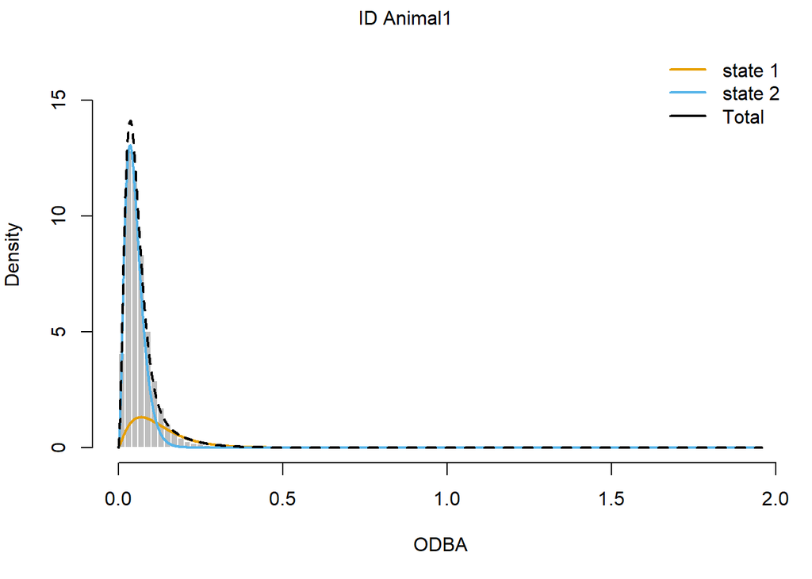

```r
plot(fit1,breaks = 80)
```

Let’s include retryFits in the fitHMM function.

```r
set.seed(147)
fit1_s2 <- fitHMM(BlacktipBData,
                  nbState = 2,
                  dist=list(ODBA="gamma"),
                  Par0 = list(ODBA=c(.1,.3,1,1)),
                  retryFits=10)
```

```
## Attempting to improve fit using random perturbation. Press 'esc' to force exit from 'fitHMM'
##
    Attempt 1 of 10 -- current log-likelihood value: 632931
    Attempt 2 of 10 -- current log-likelihood value: 632931
    Attempt 3 of 10 -- current log-likelihood value: 632931
    Attempt 4 of 10 -- current log-likelihood value: 632931
    Attempt 5 of 10 -- current log-likelihood value: 632931
    Attempt 6 of 10 -- current log-likelihood value: 632931
    Attempt 7 of 10 -- current log-likelihood value: 632931
    Attempt 8 of 10 -- current log-likelihood value: 632931.5
    Attempt 9 of 10 -- current log-likelihood value: 632931.5
    Attempt 10 of 10 -- current log-likelihood value: 632931.5
```

Seems nothing changed at all!

```r
fit1_s2_long <- fitHMM(BlacktipBData,
                  nbState = 2,
                  dist=list(ODBA="gamma"),
                  Par0 = list(ODBA=c(.1,1,1,1)))

fit1_s2_long
```

```
## Value of the maximum log-likelihood: 632931
##
##
## ODBA parameters:
## ----------------
##        state 1    state 2
## mean 0.1202486 0.05092869
## sd   0.0791671 0.02789225
##
## Regression coeffs for the transition probabilities:
## ---------------------------------------------------
##                1 -> 2    2 -> 1
## (Intercept) -2.520216 -3.789741
##
## Transition probability matrix:
## ------------------------------
##            state 1    state 2
## state 1 0.92554694 0.07445306
## state 2 0.02210193 0.97789807
##
## Initial distribution:
## ---------------------
##   state 1   state 2
## 0.4998976 0.5001024
```

```
## Computing pseudo-residuals...
```

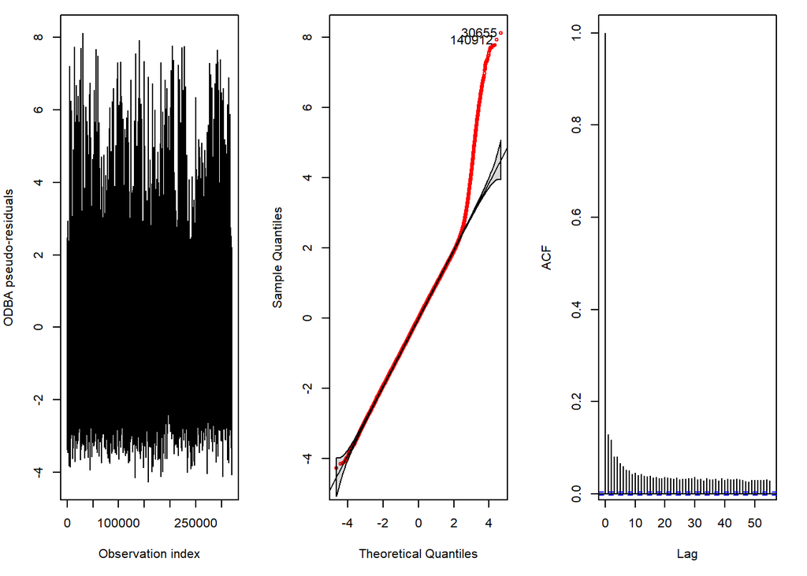

```r
plotPR(fit1)
```

We can also compute the most likely sequence of states. What can we infer from this? Is there something else we can say from this? According to fitted model, can we see if there is any interesting pattern?

```r
# identify most likely state using the Viterbi algorithm
BlacktipB$state <- viterbi(fit1)

# proportion of the behaviour states during the observed period
table(BlacktipB$state)/length(BlacktipB$state)
```

```
##
##         1         2
## 0.2088546 0.7911454
```

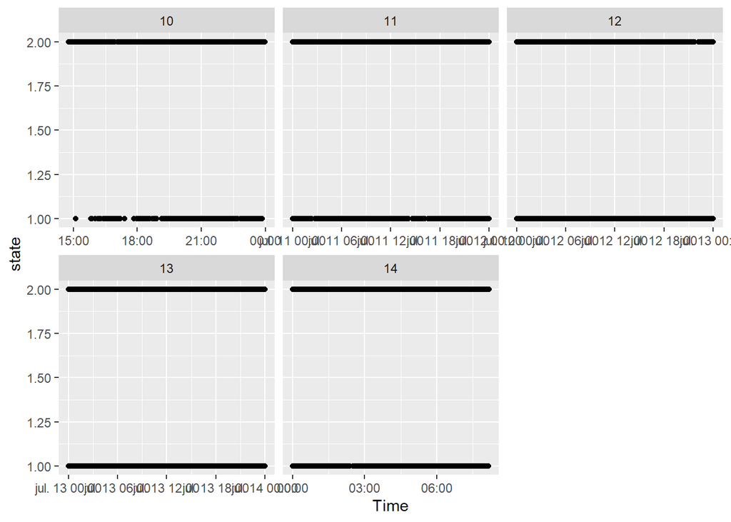

```r
BlacktipB %>% mutate(day = day(Time)) %>% ggplot(aes(Time,state)) + facet_wrap(~day,scales = "free_x") + geom_point()
```

# 4 Incorporating covariates

As in Leos-Barajas et al. 2017, we can incorporate other information that may help explain the values of ODBA. In this case, we consider the second of the day of every observation. Time of day is represented by two trigonometric functions with period 24 h, $cos(2\pi t/86,400)$ and $sin(2\pi t/86,400)$ (86 400 is the number of seconds in a day). Using the function cosinor, we can convert our data stream to something that is useful for us. As well, we need to provide the formula corresponding to the regression that will be stored in the transition probability values.

```r
# formula corresponding to the regression coefficients for the transition probabilities
formula = ~ cosinor(hour_to_sec, period = 86400)
Par0_fit2 <- getPar0(model=fit1, formula=formula)

fit2 = fitHMM(BlacktipBData,nbStates=2,dist=list(ODBA="gamma"),Par0 = Par0_fit2$Par,formula=formula)

fit2
```

```
## Value of the maximum log-likelihood: 633196.9
##
##
## ODBA parameters:
## ----------------
##         state 1    state 2
## mean 0.12067826 0.05095365
## sd   0.07935066 0.02790659
##
## Regression coeffs for the transition probabilities:
## ---------------------------------------------------
##                                             1 -> 2      2 -> 1
## (Intercept)                             -2.4297307 -3.80722355
## cosinorCos(hour_to_sec, period = 86400) -0.2043809  0.41167566
## cosinorSin(hour_to_sec, period = 86400)  0.1678336 -0.07412093
##
## Transition probability matrix (based on mean covariate values):
## ---------------------------------------------------------------
##            state 1    state 2
## state 1 0.90261901 0.09738099
## state 2 0.01450992 0.98549008
##
## Initial distribution:
## ---------------------
##   state 1   state 2
## 0.4996925 0.5003075
```

```
## Decoding state sequence... DONE
```

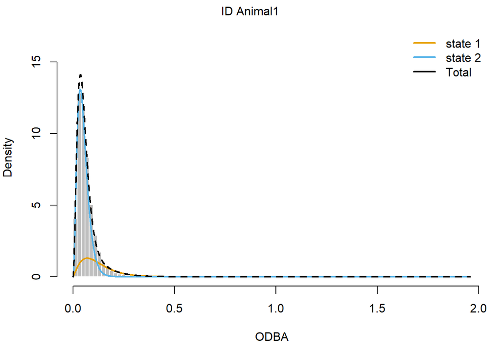

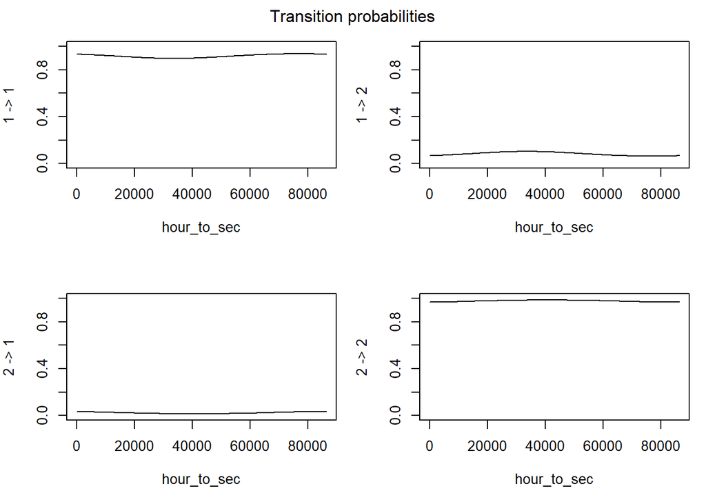

```r
plot(fit2,breaks=80)
```

Let’s explore the results. Do the coefficients vary much? What about the ACF? Did the autocorrelation decrease with this innovation?

```
## Computing pseudo-residuals...
```

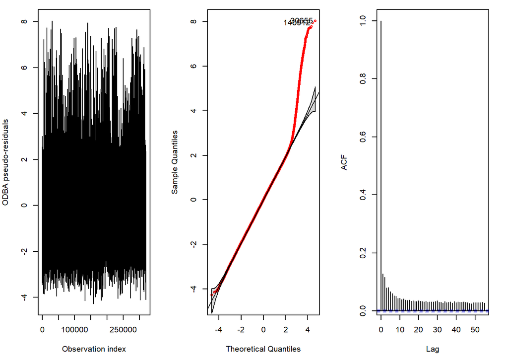

```r
plotPR(fit2)
```

We can also take a quick look at the Akaike information criteria (AIC) for the two models to do a comparison.

```r
AIC(fit1)
```

```
## [1] -1265848
```

```r
AIC(fit2)
```

```
## [1] -1266372
```

# 5 Depth Data

Tiger shark data were collected in Oahu, Hawai’i. The shark’s depth was recorded in 0.5 m intervals every 2 s over a 23 day period, from March 9 to March 31, 2009. On some days, the tiger shark inhabited varied ranges of depth levels and performed many dives whereas other days it remained relatively constant in the water column and dove less. For sharks, movement in the water column is not easily segmented into types of dives. However, dives, or simply ascending or descending, can be an important part of a shark’s behavior. We extracted a depth position every ten minutes from the available data record and sequentially computed the absolute change in depth position, $y^*_t = |d_t - d_{t-1}|$, for the tiger shark in order to understand how the depths inhabited by the shark differ across days. On some days the tiger shark tends to remain in the same part of the water column for long periods of time while on others, it tends to move up and down more frequently throughout the day. We processed the data to produce $M=144$ observations per day, across $K=21$ days, excluding the first and last days for which only partial data records were available.

```r
# Read the data
tigerShark <- read_csv("data/tigershark_depthchange10min.csv")
tigerShark = tigerShark %>% mutate(abs_change_depth = abs(Depth - lag(Depth,default = 0)))
head(tigerShark)
```

```
## # A tibble: 6 x 13
##     Date Depth Light ETemp DateTime            HST                  days minutes
##    <dbl> <dbl> <dbl> <dbl> <dttm>              <dttm>              <dbl>   <dbl>
## 1 39882.   4     197  21.6 2009-03-10 01:10:00 2009-03-09 15:10:00     9     910
## 2 39882.   4     200  21.4 2009-03-10 01:20:00 2009-03-09 15:20:00     9     920
## 3 39882.  10     188  21.4 2009-03-10 01:30:00 2009-03-09 15:30:00     9     930
## 4 39882.  17     174  21.3 2009-03-10 01:40:00 2009-03-09 15:40:00     9     940
## 5 39882.  14.5   180  21.4 2009-03-10 01:50:00 2009-03-09 15:50:00     9     950
## 6 39882.  13.5   181  21.2 2009-03-10 02:00:00 2009-03-09 16:00:00     9     960
## # ... with 5 more variables: five <dbl>, ten <dbl>, second <dbl>, depthc <dbl>,
## #   abs_change_depth <dbl>
```

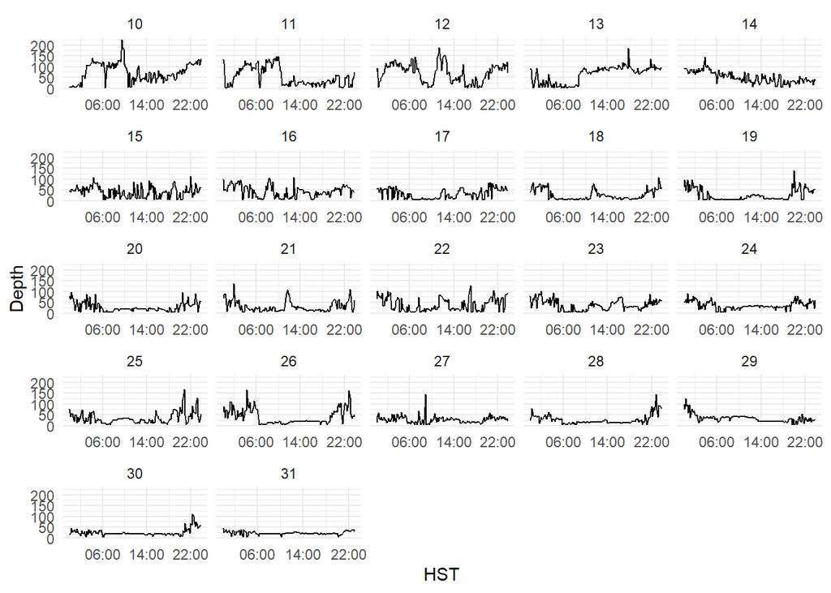

```r
tigerShark %>%
  filter(days != 9) %>%
  ggplot(aes(x=HST,y=Depth)) + facet_wrap(~days,scales = "free_x") + geom_line() +
  scale_x_datetime(breaks= "8 hour", date_labels = "%H:%M") + theme_minimal()
```

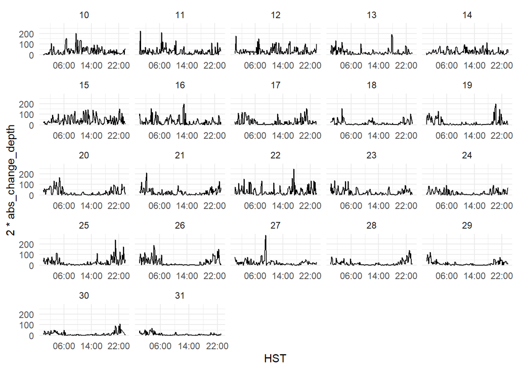

```r
tigerShark %>% filter(days != 9) %>%
  ggplot(aes(x=HST,y=2*abs_change_depth)) + facet_wrap(~days,scales = "free_x") + geom_line() +
  scale_x_datetime(breaks= "8 hour", date_labels = "%H:%M") + theme_minimal()
```

# 6 Hierarchical Hidden Markov models

The general idea of a hiearchical HMM is that there are (at least) two behavioral processes of interest but they manifest at different temporal scales. For instance, here we will look at both fine-scale vertical movement behavior and across day movement behavior as well. These are referred to as fine state-level (10 min) and coarse state-level behaviors (day).

To fit these models in momentuHMM, we will introduce a new column called “level”.

```r
days_range = unique(tigerShark$days)
tigerSharkData <- NULL

for(i in days_range){
  coarseInd <- data.frame(tigerShark %>% filter(days == i) %>%
                                   filter(row_number() == 1) %>% select(HST),
                                 days = i,
                                 level=c("1","2i"),
                                 abs_change_depth=NA)
  tmp <- rbind(coarseInd,tigerShark %>% filter(days == i) %>% mutate(level = "2") %>%
                 select(HST,days,level,abs_change_depth))
  tigerSharkData <- rbind(tigerSharkData,tmp)
}

head(tigerSharkData)
```

```
##                   HST days level abs_change_depth
## 1 2009-03-09 15:10:00    9     1               NA
## 2 2009-03-09 15:10:00    9    2i               NA
## 3 2009-03-09 15:10:00    9     2                4
## 4 2009-03-09 15:20:00    9     2                0
## 5 2009-03-09 15:30:00    9     2                6
## 6 2009-03-09 15:40:00    9     2                7
```

```r
tigerSharkData = prepData(tigerSharkData,
                          coordNames = NULL, hierLevels = c("1","2i","2"))


# summarize prepared data
summary(tigerSharkData, dataNames = names(tigerSharkData)[-1])
```

```
## Hierarchical HMM data for 1 individual:
##
## Animal1 -- 3262 observations
##
##
## Data summaries:
##
##       HST                           days    level     abs_change_depth
##  Min.   :2009-03-09 15:10:00   Min.   : 9   1 :  23   Min.   :  0.0
##  1st Qu.:2009-03-15 04:42:30   1st Qu.:15   2i:  23   1st Qu.:  1.5
##  Median :2009-03-20 18:55:00   Median :20   2 :3216   Median :  6.5
##  Mean   :2009-03-20 18:49:24   Mean   :20             Mean   : 12.4
##  3rd Qu.:2009-03-26 08:47:30   3rd Qu.:26             3rd Qu.: 17.5
##  Max.   :2009-03-31 23:00:00   Max.   :31             Max.   :141.0
##                                                       NA's   :46
```

However, one of the difficulties with hierarchical HMMs is the construction of the number of states, just like in regular HMMs! Here we choose three fine-scale states as that has been tested for this data to produce the best compromise between model fit and model complexity, and two coarse-scale states.

```r
### define hierarchical HMM
### states 1-3 = coarse state 1 (nontravelling)
### states 4-6 = coarse state 2 (travelling)
hierStates <- data.tree::Node$new("tiger shark HHMM states")
hierStates$AddChild(name="nontravelling")
hierStates$nontravelling$AddChild(name="nt1", state=1)
hierStates$nontravelling$AddChild(name="nt2", state=2)
hierStates$nontravelling$AddChild(name="nt3", state=3)
hierStates$AddChild(name="travelling")
hierStates$travelling$AddChild(name="t1", state=4)
hierStates$travelling$AddChild(name="t2", state=5)
hierStates$travelling$AddChild(name="t3", state=6)

plot(hierStates)
```

[interactive chart not shown]

```r
#Alternative way for specifying
hierStates <- data.tree::as.Node(list(name="tiger shark HHMM states",
                                      nontravelling=list(nt1=list(state=1),
                                                nt2=list(state=2),
                                                nt3=list(state=3)),
                                      travelling=list(t1=list(state=4),
                                                    t2=list(state=5),
                                                    t3=list(state=6))))
```

he name for any of the “children” added to a node are user-specified and are akin to the stateNames argument in fitHMM for a standard HMM. While these names are arbitrary, the name and state attributes must be unique.

```r
# data stream distributions
# level 1 = coarse scale (no data streams)
# level 2 = fine scale (dive_duration, maximum_depth, dive_wiggliness)
hierDist <- data.tree::Node$new("tiger shark HHMM dist")
hierDist$AddChild(name="level1")
hierDist$AddChild(name="level2")
hierDist$level2$AddChild(name="abs_change_depth", dist="gamma")
plot(hierDist)
```

[interactive chart not shown]

The Node attribute dist is required in hierDist and specifies the probability dis- tribution for each data stream at each level of the hierarchy (Figure 14. In this case, level1 (corresponding to coarse-scale observations with level=1) has no data streams, and each of the data streams for level2 (corresponding to fine-scale observations with level=2) is assigned a gamma distribution with an additional point-mass on zero to account for zero changes in depth.

We did not include any covariates on the t.p.m. or initial distribution for either level of the hierarchy, but, for demonstration purposes, here is how we would use the hierFormula and hierFormulaDelta arguments to specify the t.p.m. and initial distribution formula for each level of the hierarchy in fitHMM:

```r
# define hierarchical t.p.m. formula(s)
hierFormula <- data.tree::Node$new("harbor porpoise HHMM formula")
hierFormula$AddChild(name="level1", formula=~1)
hierFormula$AddChild(name="level2", formula=~1)

# define hierarchical initial distribution formula(s)
hierFormulaDelta <- data.tree::Node$new("harbor porpoise HHMM formulaDelta")
hierFormulaDelta$AddChild(name="level1", formulaDelta=~1)
hierFormulaDelta$AddChild(name="level2", formulaDelta=~1)
```

We can assume the data stream probability distributions do not depend on the coarse-scale state, so we can constrain the state-dependent parameters for states 1 (“nt1”) and 4 (“t1”), states 2 (“nt2”) and 5 (“t2”), and states 3 (“nt3”) and 6 (“t3”) to be equal using the DM argument:

```r
# defining starting values
cd.mu0 = rep(c(5,50,100),hierStates$count)
cd.sigma0 = rep(c(5,15,40),hierStates$count)
cd.pi0 = rep(c(0.2,0.01,0.01),hierStates$count)

Par0 = list(abs_change_depth = c(cd.mu0,cd.sigma0,cd.pi0))

nbStates <- length(hierStates$Get("state",filterFun=data.tree::isLeaf))
```

```r
# constrain fine-scale data stream distributions to be same
cd_DM <- matrix(cbind(kronecker(c(1,1,0,0,0,0),diag(3)),
                      kronecker(c(0,0,1,1,0,0),diag(3)),
                      kronecker(c(0,0,0,0,1,1),diag(3))),
                nrow=nbStates*3,
                ncol=9,
                dimnames=list(c(paste0("mean_",1:nbStates),
                                paste0("sd_",1:nbStates),
                                paste0("zeromass_",1:nbStates)),
                              paste0(rep(c("mean","sd","zeromass"),each=3),
                                     c("_14:(Intercept)",
                                       "_25:(Intercept)",
                                       "_36:(Intercept)"))))
DM = list(abs_change_depth = cd_DM)
```

```r
# get initial parameter values for data stream probability distributions
Par <- getParDM(tigerSharkData,hierStates=hierStates,hierDist=hierDist,
                Par=Par0,DM=DM)

# check hierarchical model specification and parameters
checkPar0(tigerSharkData,hierStates=hierStates,hierDist=hierDist,Par0=Par,
          hierFormula=hierFormula,hierFormulaDelta=hierFormulaDelta,
          DM=DM)
```

```
##
## Regression coeffs for abs_change_depth parameters:
## --------------------------------------------------
##      mean_14:(Intercept) mean_25:(Intercept) mean_36:(Intercept)
## [1,]            1.609438            3.912023             4.60517
##      sd_14:(Intercept) sd_25:(Intercept) sd_36:(Intercept)
## [1,]          1.609438           2.70805          3.688879
##      zeromass_14:(Intercept) zeromass_25:(Intercept) zeromass_36:(Intercept)
## [1,]               -1.386294                -4.59512                -4.59512
##
## ----------------------------------------------------------
## Regression coeffs for the transition probabilities (beta):
## ----------------------------------------------------------
## -------------------------  level1  -----------------------
##                       1 -> 4 4 -> 1
## I((level == "1") * 1)      1      2
##
## -------------------------  level2  -----------------------
##                       1 -> 2 1 -> 3 2 -> 2 2 -> 3 3 -> 2 3 -> 3
## I((level == "2") * 1)      1      2      3      4      5      6
##
##                       4 -> 5 4 -> 6 5 -> 5 5 -> 6 6 -> 5 6 -> 6
## I((level == "2") * 1)      1      2      3      4      5      6
##
## ----------------------------------------------------------
##
## ----------------------------------------------------------
## Regression coeffs for the initial distribution (delta):
## ----------------------------------------------------------
## ------------------------  level1  ------------------------
##             state 4
## (Intercept)       1
##
## ------------------------  level2  ------------------------
##                        state 2 state 3
## I((level == "2i") * 1)       1       2
##
##                        state 5 state 6
## I((level == "2i") * 1)       1       2
##
## ----------------------------------------------------------
```

When interpreting the output, we are looking at two parts:

- the estimated state-dependent distribution parameteres
- the different transition probability matrices that define the differences at the coarse-scale

```r
# fit hierarchical HMM
hhmm <- fitHMM(data=tigerSharkData,hierStates=hierStates,hierDist=hierDist,
               #hierFormula=hierFormula,#hierFormulaDelta=hierFormulaDelta,
               Par0=Par,#hierBeta=hierBeta,hierDelta=hierDelta,
               DM=DM,nlmPar=list(hessian=FALSE))
hhmm
```

```
## Value of the maximum log-likelihood: -10961.5
##
##
## abs_change_depth parameters:
## ----------------------------
##                nt1          nt2         nt3        t1           t2          t3
## mean     3.4138952 7.712878e-04 18.48346792 3.4138952 7.712878e-04 18.48346792
## sd       3.2111075 4.312410e+02 16.87558189 3.2111075 4.312410e+02 16.87558189
## zeromass 0.1684493 3.781626e-02  0.01888036 0.1684493 3.781626e-02  0.01888036
##
##
## ---------------------------------------------------------------
## Regression coeffs for the transition probabilities:
## ---------------------------------------------------------------
## --------------------------  level1  ---------------------------
##                           1 -> 4     4 -> 1
## I((level == "1") * 1) -0.9430715 -0.3776745
##
## --------------------------  level2  ---------------------------
##                          1 -> 2    1 -> 3    2 -> 2   2 -> 3    3 -> 2  3 -> 3
## I((level == "2") * 1) -37.81833 -4.086858 -4.199947 4.335918 -23.87418 4.15029
##
##                          4 -> 5    4 -> 6    5 -> 5   5 -> 6    6 -> 5   6 -> 6
## I((level == "2") * 1) -33.12451 -1.429031 -6.869803 4.789274 -31.69066 2.539621
##
## ---------------------------------------------------------------
##
## ---------------------------------------------------------------
## Transition probability matrix (based on mean covariate values):
## ---------------------------------------------------------------
## --------------------------  level1  ---------------------------
##               nontravelling travelling
## nontravelling     0.7197197  0.2802803
## travelling        0.4066879  0.5933121
##
## --------------------------  level2  ---------------------------
##            nt1          nt2        nt3
## nt1 0.98348539 3.702335e-17 0.01651461
## nt2 0.01291822 1.937264e-04 0.98688806
## nt3 0.01551532 6.642600e-13 0.98448468
```

[output cut: 24 more lines]

```
## --------------------------------------------------
## Initial distribution:
## --------------------------------------------------
## --------------------  level1  --------------------
##            nontravelling   travelling
## ID:Animal1     0.9999963 3.710577e-06
##
## --------------------  level2  --------------------
##                      nt1          nt2       nt3
## nontravelling 0.05733259 0.0005215114 0.9421459
##
##                   t1           t2        t3
## travelling 0.1678072 0.0001257684 0.8320671
##
## --------------------------------------------------
```

We can also use the same functions as before to visualize our model results.

```
## Decoding state sequence... DONE
## Decoding hierarchical state sequence... DONE
```

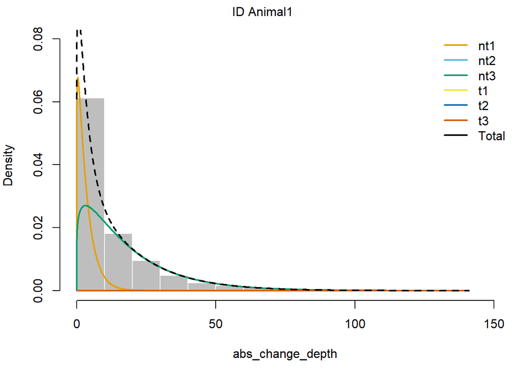

```r
plot(hhmm)
```

```
## Computing pseudo-residuals...
```

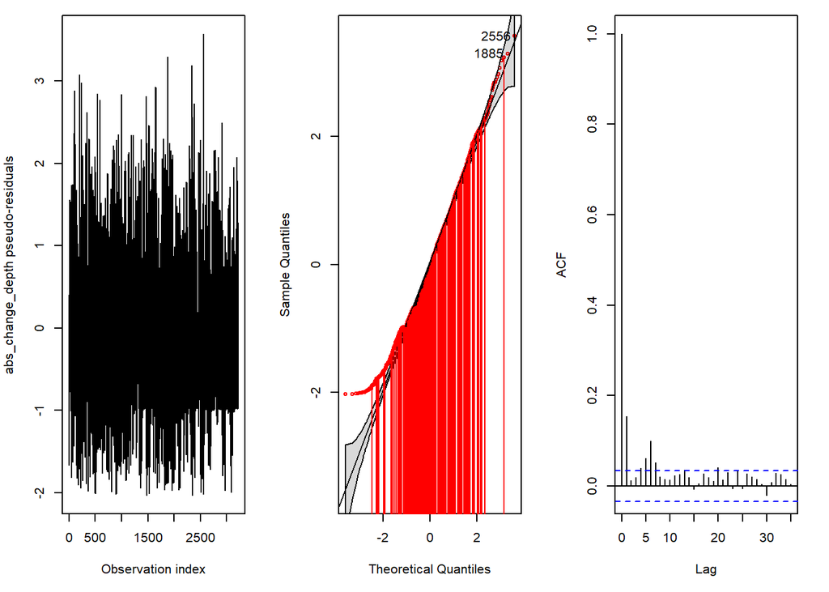

```r
plotPR(hhmm)
```

# 7 Exercises

Generate new data streams from original datasets (overall mean in different time periods). Does the ACF changes between these data sets? How are they compared to the original data set? What can you say about this?

- Instead of considering observations every second, create a new data set for 10 sec, another for 30 s and 1 min. Code below will generate such data sets. Fit a basic HMM for the each one of these new datasets. Did the ACF changed? does they seems to not break the conditional independence? (i.e., the ACF values are lower?).

```r
BlacktipB = BlacktipB %>%
  mutate(group_10s = case_when(sec <= 10 ~ 1,
                               10 < sec & sec <= 20 ~ 2,
                               20 < sec & sec <= 30 ~ 3,
                               30 < sec & sec <= 40~ 4,
                               40 < sec & sec <= 50 ~ 5,
                               50 < sec & sec <= 60 ~ 6,
                               TRUE ~ -1),
         group_30s = case_when(sec <= 30 ~ 1,
                               30 < sec & sec <= 60 ~ 2,
                               TRUE ~ -1)) %>%
  group_by(Time,group_10s) %>% mutate(ODBA_mean_10s = mean(ODBA)) %>% ungroup() %>%
  group_by(Time,group_30s) %>% mutate(ODBA_mean_30s = mean(ODBA)) %>% ungroup() %>%
  group_by(Time) %>% mutate(ODBA_mean_60s = mean(ODBA)) %>%
  mutate(hour_to_sec_10s = floor((hour_to_sec-1)/10+1),
         hour_to_sec_30s = floor((hour_to_sec-1)/30+1),
         hour_to_sec_60s = floor((hour_to_sec-1)/60+1))

BlacktipB_10s = BlacktipB %>% group_by(Time,group_10s) %>% filter(row_number() == 1) %>%
  ungroup() %>% select(Time,Depth,ODBA_mean_10s,hour_to_sec_10s)
BlacktipB_30s = BlacktipB %>% group_by(Time,group_30s) %>% filter(row_number() == 1) %>%
  ungroup() %>% select(Time,Depth,ODBA_mean_30s,hour_to_sec_30s)
BlacktipB_60s = BlacktipB %>% group_by(Time) %>% filter(row_number() == 1) %>%
  ungroup() %>% select(Time,Depth,ODBA_mean_60s,hour_to_sec_60s)

BlacktipB = BlacktipB %>% select(Time,Depth,ODBA,hour_to_sec)
```

Fit a 3-state HMM with no covariates and fit another one using time as a covariate. What happents to the ACF? According to loglikelihood and AIC, which model is better?

- Reproduce the analysis from the blacktip shark data, but now include three states. What about the ACF? Did something change compared to the 2-state HMM? Now include hour_to_sec as a covariate and fit a new model. What happen with the AIC values and the loglikelihood? According to these, what seems to be a better model?